# 01_EDA

Sonal Mendiratta

5/14/2020

# Objective:

- Understanding the data
- Visualization

# Understanding the data

### 1.air_reserve

- air_store_id - the restaurant’s id in the air system
- visit_datetime - the time of the reservation
- reserve_datetime - the time the reservation was made
- reserve_visitors - the number of visitors for that reservation

```r
air_reserve <- data.frame(read.csv("air_reserve.csv"))
head(air_reserve)
```

```
##           air_store_id      visit_datetime    reserve_datetime
## 1 air_877f79706adbfb06 2016-01-01 19:00:00 2016-01-01 16:00:00
## 2 air_db4b38ebe7a7ceff 2016-01-01 19:00:00 2016-01-01 19:00:00
## 3 air_db4b38ebe7a7ceff 2016-01-01 19:00:00 2016-01-01 19:00:00
## 4 air_877f79706adbfb06 2016-01-01 20:00:00 2016-01-01 16:00:00
## 5 air_db80363d35f10926 2016-01-01 20:00:00 2016-01-01 01:00:00
## 6 air_db80363d35f10926 2016-01-02 01:00:00 2016-01-01 16:00:00
##   reserve_visitors
## 1                1
## 2                3
## 3                6
## 4                2
## 5                5
## 6                2
```

```r
dim(air_reserve)
```

```
## [1] 92378     4
```

```r
names(air_reserve)
```

```
## [1] "air_store_id"     "visit_datetime"   "reserve_datetime"
## [4] "reserve_visitors"
```

```r
air_reserve %>% distinct(air_store_id) %>% nrow()
```

```
## [1] 314
```

314 unique stores in reservation data

### 2. air_store_info

Information around air restaurants

```r
air_store_info <- data.frame(read.csv("air_store_info.csv"))
head(air_store_info)
```

```
##           air_store_id air_genre_name                air_area_name
## 1 air_0f0cdeee6c9bf3d7 Italian/French Hyōgo-ken Kōbe-shi Kumoidōri
## 2 air_7cc17a324ae5c7dc Italian/French Hyōgo-ken Kōbe-shi Kumoidōri
## 3 air_fee8dcf4d619598e Italian/French Hyōgo-ken Kōbe-shi Kumoidōri
## 4 air_a17f0778617c76e2 Italian/French Hyōgo-ken Kōbe-shi Kumoidōri
## 5 air_83db5aff8f50478e Italian/French Tōkyō-to Minato-ku Shibakōen
## 6 air_99c3eae84130c1cb Italian/French Tōkyō-to Minato-ku Shibakōen
##   latitude longitude
## 1 34.69512  135.1979
## 2 34.69512  135.1979
## 3 34.69512  135.1979
## 4 34.69512  135.1979
## 5 35.65807  139.7516
## 6 35.65807  139.7516
```

```r
dim(air_store_info)
```

```
## [1] 829   5
```

```r
air_store_info %>% distinct(air_store_id) %>% nrow()
```

```
## [1] 829
```

829 unique stores

### 3. air_visit_data

Visit data for air restaurants

```r
air_visit_data  <- data.frame(read.csv("air_visit_data.csv"))
head(air_visit_data)
```

```
##           air_store_id visit_date visitors
## 1 air_ba937bf13d40fb24 2016-01-13       25
## 2 air_ba937bf13d40fb24 2016-01-14       32
## 3 air_ba937bf13d40fb24 2016-01-15       29
## 4 air_ba937bf13d40fb24 2016-01-16       22
## 5 air_ba937bf13d40fb24 2016-01-18        6
## 6 air_ba937bf13d40fb24 2016-01-19        9
```

```r
dim(air_visit_data)
```

```
## [1] 252108      3
```

```r
names(air_visit_data)
```

```
## [1] "air_store_id" "visit_date"   "visitors"
```

```r
air_visit_data %>% distinct(air_store_id) %>% nrow()
```

```
## [1] 829
```

829 unique stores

### 4. date_info

calendar date information - day of the week and holiday

```r
date_info <- data.frame(read.csv("date_info.csv"))
head(date_info)
```

```
##   calendar_date day_of_week holiday_flg
## 1    2016-01-01      Friday           1
## 2    2016-01-02    Saturday           1
## 3    2016-01-03      Sunday           1
## 4    2016-01-04      Monday           0
## 5    2016-01-05     Tuesday           0
## 6    2016-01-06   Wednesday           0
```

```r
dim(date_info)
```

```
## [1] 517   3
```

```r
str(date_info)
```

```
## 'data.frame':    517 obs. of  3 variables:
##  $ calendar_date: Factor w/ 517 levels "2016-01-01","2016-01-02",..: 1 2 3 4 5 6 7 8 9 10 ...
##  $ day_of_week  : Factor w/ 7 levels "Friday","Monday",..: 1 3 4 2 6 7 5 1 3 4 ...
##  $ holiday_flg  : int  1 1 1 0 0 0 0 0 0 0 ...
```

```r
date_info %>% distinct(calendar_date) %>% nrow()
```

```
## [1] 517
```

517 unique dates

### 5. hpg_reserve

details of reservations made in the hpg system

```r
hpg_reserve <- data.frame(read.csv("hpg_reserve.csv"))
head(hpg_reserve)
```

```
##           hpg_store_id      visit_datetime    reserve_datetime
## 1 hpg_c63f6f42e088e50f 2016-01-01 11:00:00 2016-01-01 09:00:00
## 2 hpg_dac72789163a3f47 2016-01-01 13:00:00 2016-01-01 06:00:00
## 3 hpg_c8e24dcf51ca1eb5 2016-01-01 16:00:00 2016-01-01 14:00:00
## 4 hpg_24bb207e5fd49d4a 2016-01-01 17:00:00 2016-01-01 11:00:00
## 5 hpg_25291c542ebb3bc2 2016-01-01 17:00:00 2016-01-01 03:00:00
## 6 hpg_28bdf7a336ec6a7b 2016-01-01 17:00:00 2016-01-01 15:00:00
##   reserve_visitors
## 1                1
## 2                3
## 3                2
## 4                5
## 5               13
## 6                2
```

```r
dim(hpg_reserve)
```

```
## [1] 2000320       4
```

```r
hpg_reserve %>% distinct(hpg_store_id) %>% nrow()
```

```
## [1] 13325
```

13325 distinct stores

###6. hpg_store_info information around hpg restaurants

```r
hpg_store_info <- data.frame(read.csv("hpg_store_info.csv"))
head(hpg_store_info)
```

```
##           hpg_store_id hpg_genre_name                 hpg_area_name
## 1 hpg_6622b62385aec8bf Japanese style Tōkyō-to Setagaya-ku Taishidō
## 2 hpg_e9e068dd49c5fa00 Japanese style Tōkyō-to Setagaya-ku Taishidō
## 3 hpg_2976f7acb4b3a3bc Japanese style Tōkyō-to Setagaya-ku Taishidō
## 4 hpg_e51a522e098f024c Japanese style Tōkyō-to Setagaya-ku Taishidō
## 5 hpg_e3d0e1519894f275 Japanese style Tōkyō-to Setagaya-ku Taishidō
## 6 hpg_530cd91db13b938e Japanese style Tōkyō-to Setagaya-ku Taishidō
##   latitude longitude
## 1 35.64367  139.6682
## 2 35.64367  139.6682
## 3 35.64367  139.6682
## 4 35.64367  139.6682
## 5 35.64367  139.6682
## 6 35.64367  139.6682
```

```r
dim(hpg_store_info)
```

```
## [1] 4690    5
```

```r
hpg_store_info %>% distinct(hpg_store_id) %>% nrow()
```

```
## [1] 4690
```

4690 unique stores

###7. store_id_relation relation between hpg and air store ids

```r
store_id_relation <- data.frame(read.csv("store_id_relation.csv"))
head(store_id_relation)
```

```
##           air_store_id         hpg_store_id
## 1 air_63b13c56b7201bd9 hpg_4bc649e72e2a239a
## 2 air_a24bf50c3e90d583 hpg_c34b496d0305a809
## 3 air_c7f78b4f3cba33ff hpg_cd8ae0d9bbd58ff9
## 4 air_947eb2cae4f3e8f2 hpg_de24ea49dc25d6b8
## 5 air_965b2e0cf4119003 hpg_653238a84804d8e7
## 6 air_a38f25e3399d1b25 hpg_50378da9ffb9b6cd
```

```r
dim(store_id_relation)
```

```
## [1] 150   2
```

```r
store_id_relation %>% distinct(air_store_id) %>% nrow()
```

```
## [1] 150
```

relation between hpg id and air id for 150 stores

###8. sample_submission

- final data - need visitor count for each restaurant
- dependent variable - Visitors
- we are not predicting number of visits in a day but number of visitors in a day!

```r
sample_submission <- data.frame(read.csv("sample_submission.csv"))
head(sample_submission)
```

```
##                                id visitors
## 1 air_00a91d42b08b08d9_2017-04-23        0
## 2 air_00a91d42b08b08d9_2017-04-24        0
## 3 air_00a91d42b08b08d9_2017-04-25        0
## 4 air_00a91d42b08b08d9_2017-04-26        0
## 5 air_00a91d42b08b08d9_2017-04-27        0
## 6 air_00a91d42b08b08d9_2017-04-28        0
```

```r
dim(sample_submission)
```

```
## [1] 32019     2
```

# Visualization

- distribution of restaurancts by genre
- distribution of restaurants by area
- distribution of visits by holidays
- distribution of visits during the week
- distribution of visits overall

## Data Pre-processing

```r
# Converting date from factor to date format in all datasets

# air_visit_data
air_visit_data$visit_date <- ymd(air_visit_data$visit_date)
head(air_visit_data)
```

```
##           air_store_id visit_date visitors
## 1 air_ba937bf13d40fb24 2016-01-13       25
## 2 air_ba937bf13d40fb24 2016-01-14       32
## 3 air_ba937bf13d40fb24 2016-01-15       29
## 4 air_ba937bf13d40fb24 2016-01-16       22
## 5 air_ba937bf13d40fb24 2016-01-18        6
## 6 air_ba937bf13d40fb24 2016-01-19        9
```

```r
# air_reserve
air_reserve$reserve_datetime <- ymd_hms(air_reserve$reserve_datetime)
air_reserve$visit_datetime <- ymd_hms(air_reserve$visit_datetime)

# hpg_reserve
hpg_reserve$reserve_datetime <- ymd_hms(hpg_reserve$reserve_datetime)
hpg_reserve$visit_datetime <- ymd_hms(hpg_reserve$visit_datetime)
head(hpg_reserve)
```

```
##           hpg_store_id      visit_datetime    reserve_datetime
## 1 hpg_c63f6f42e088e50f 2016-01-01 11:00:00 2016-01-01 09:00:00
## 2 hpg_dac72789163a3f47 2016-01-01 13:00:00 2016-01-01 06:00:00
## 3 hpg_c8e24dcf51ca1eb5 2016-01-01 16:00:00 2016-01-01 14:00:00
## 4 hpg_24bb207e5fd49d4a 2016-01-01 17:00:00 2016-01-01 11:00:00
## 5 hpg_25291c542ebb3bc2 2016-01-01 17:00:00 2016-01-01 03:00:00
## 6 hpg_28bdf7a336ec6a7b 2016-01-01 17:00:00 2016-01-01 15:00:00
##   reserve_visitors
## 1                1
## 2                3
## 3                2
## 4                5
## 5               13
## 6                2
```

```r
# date_info
date_info$calendar_date <- ymd(date_info$calendar_date)
date_info$day_of_week <- weekdays(date_info$calendar_date)
```

## AIR Restaurants

```r
air_visit_store <- sqldf("select a.*,
                                 b.air_genre_name,
                                 b.air_area_name,
                                 b.latitude,
                                 b.longitude,
                                 c.day_of_week,
                                 c.holiday_flg
                         from air_visit_data a
                         left join air_store_info b
                         on a.air_store_id = b.air_store_id
                         left join date_info c
                         on a.visit_date = c.calendar_date")
```

Using air_visit_data here as it as data for 829 unique stores

## number of restaurants by genre

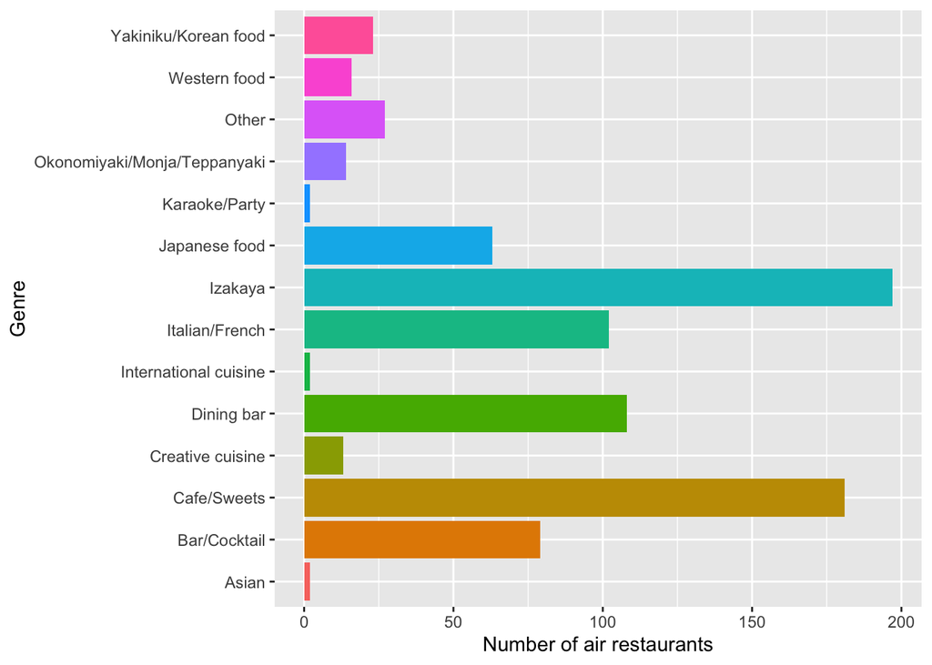

```r
air_visit_store %>%
  group_by(air_genre_name) %>%
  summarize(stores = n_distinct(air_store_id)) %>%
  ggplot(aes(x = air_genre_name,  y = stores, fill = air_genre_name)) +
  geom_col() +
  coord_flip() +
  theme(legend.position = "none") +
  labs(x = "Genre", y = "Number of air restaurants")
```

Majority of the restaurants are of Izakya and Cafe/Sweets genre

## number of restaurants by area

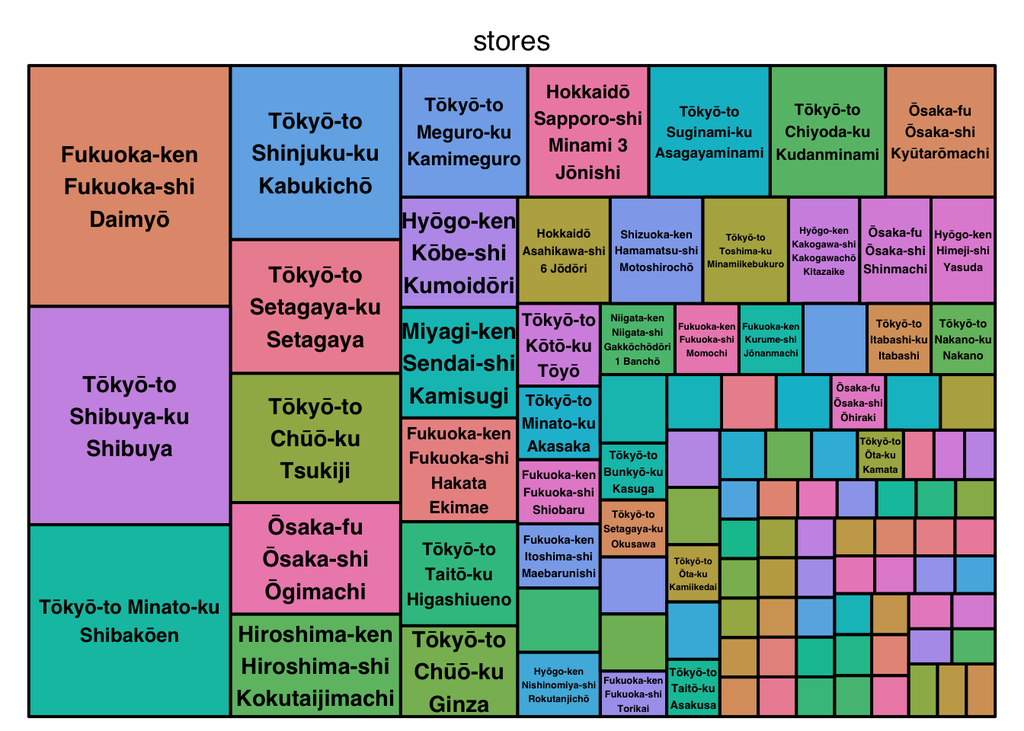

```r
air_visit_store %>%
  group_by(air_area_name) %>%
  summarize(stores = n_distinct(air_store_id)) %>%
  treemap(index="air_area_name",
        vSize="stores",
        type="index")
```

Tip 3 populated areas are: Fukuo.., Tokyo.. Tokyo..

## Day of the week

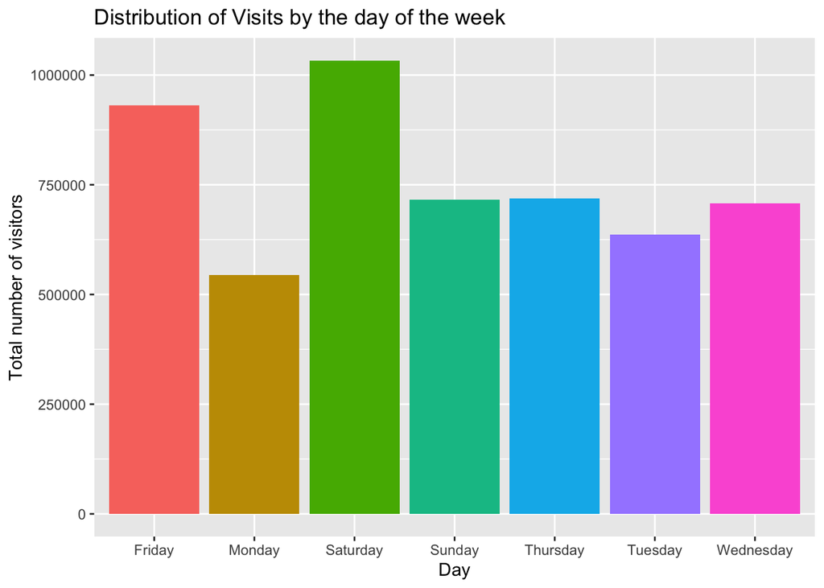

```r
air_visit_store %>%
  group_by(day_of_week) %>%
  summarise(visits = sum(visitors)) %>%
  ggplot(aes(day_of_week, visits, fill = day_of_week)) +
  geom_col() +
  theme(legend.position = "none") +
  labs(x = "Day", y = "Total number of visitors") +
  ggtitle("Distribution of Visits by the day of the week")
```

Highest number of visits are on Saturday followed by Friday

## Genre

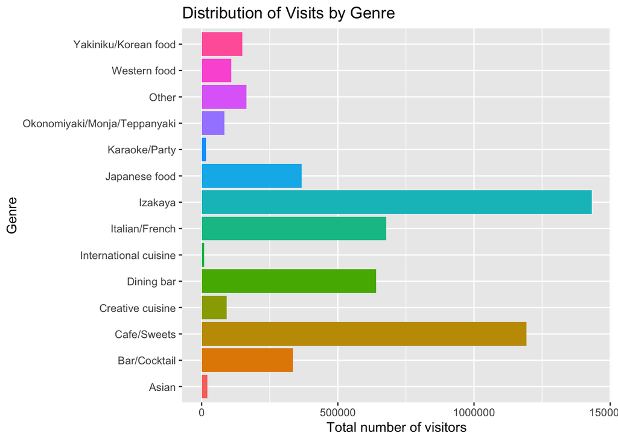

```r
air_visit_store %>%
  group_by(air_genre_name) %>%
  summarise(visits = sum(visitors)) %>%
  ggplot(aes(air_genre_name, visits, fill = air_genre_name)) +
  geom_col() +
  theme(legend.position = "none") +
  labs(x = "Genre", y = "Total number of visitors") +
  ggtitle("Distribution of Visits by Genre")+
  coord_flip()
```

Majority of the visits are also in the same top 2 genres

## Holidays

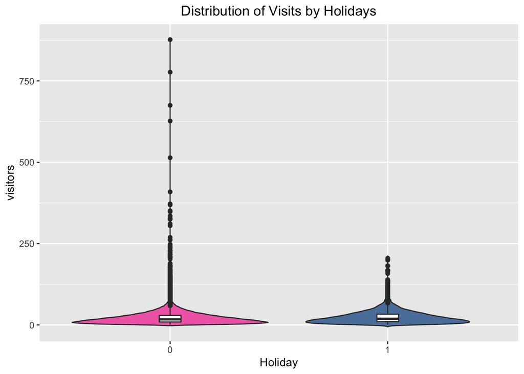

```r
test <- air_visit_store
test$holiday_flg <- as.factor(test$holiday_flg)
ggplot(test,aes(x = holiday_flg,y = visitors, fill = holiday_flg, group = holiday_flg))+
  geom_violin(trim=FALSE, alpha = 0.7) +
  theme(legend.position="none")+
  ggtitle("Distribution of Visits by Holidays")+
  theme(plot.title=element_text(hjust=0.5))+
  geom_boxplot(width=0.1,fill="white")+
  scale_fill_manual(values=c("#F2359D", "#034C8C")) +
  xlab("Holiday")
```

Interestingly, holidays do not really have an impact on the visitors.

## Holidays on weekdays

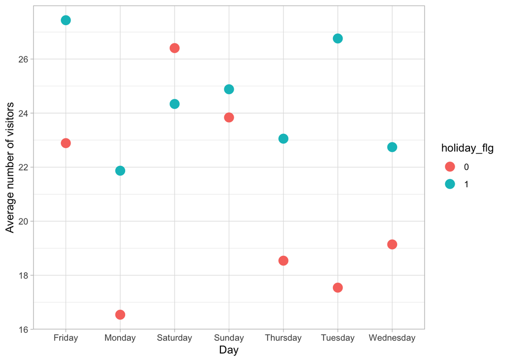

```r
test <- air_visit_store
test$holiday_flg <- as.factor(test$holiday_flg)
test %>%
  group_by(day_of_week, holiday_flg) %>%
  summarise(mean_visitors = mean(visitors)) %>%
  ggplot(aes(x=day_of_week, y=mean_visitors, color=holiday_flg)) +
    geom_point(size=4) +
  xlab("Day")+
  ylab("Average number of visitors")+
  theme_light()
```

More number of visits on a weekday if it is a holiday

## Time series

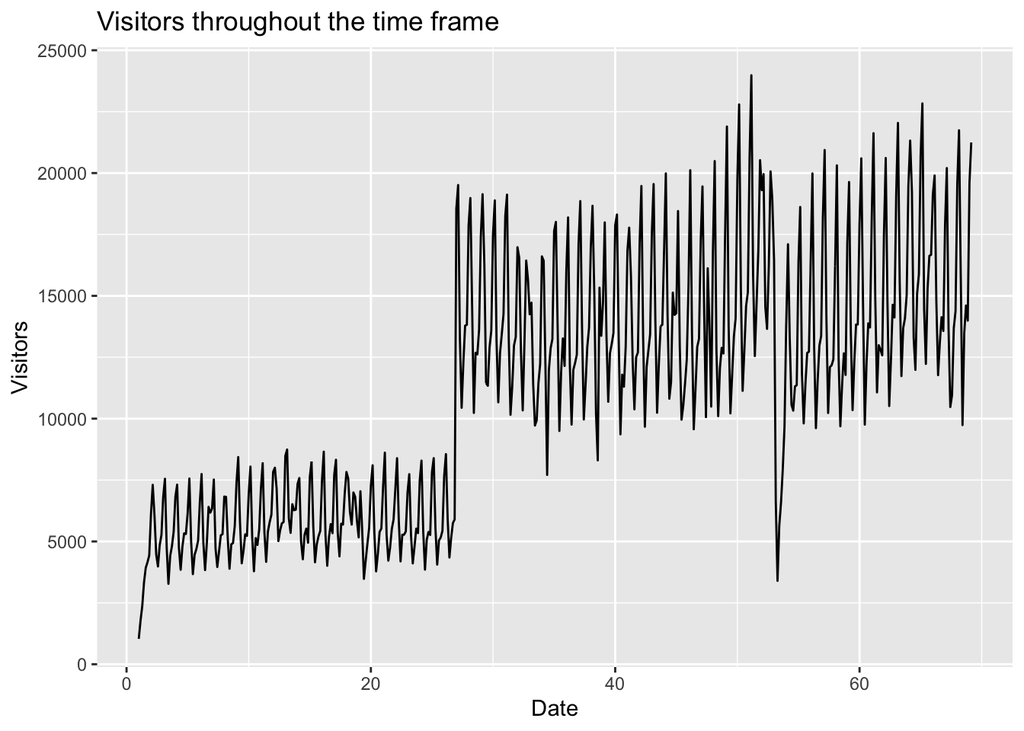

```r
air_vis <- subset(air_visit_store, select = c("visit_date","visitors"))
air_vis1 <- air_vis %>%
  group_by(visit_date) %>%
  summarize(visits = sum(visitors))

air_vis_ts <- ts(air_vis1[,2], frequency = 7)
autoplot(air_vis_ts) + xlab("Date") + ylab("Visitors") + ggtitle("Visitors throughout the time frame")
```

```r
auto <- auto.arima(air_vis_ts)
summary(auto)
```

```
## Series: air_vis_ts
## ARIMA(1,0,2)(1,1,1)[7] with drift
##
## Coefficients:
##          ar1      ma1      ma2    sar1     sma1    drift
##       0.9270  -0.1167  -0.3475  0.0759  -0.8666  26.6872
## s.e.  0.0292   0.0561   0.0538  0.0553   0.0262  10.1735
##
## sigma^2 estimated as 1844145:  log likelihood=-4067.36
## AIC=8148.72   AICc=8148.96   BIC=8177.8
##
## Training set error measures:
##                    ME     RMSE      MAE       MPE     MAPE      MASE
## Training set 4.655281 1339.399 811.5004 -1.321262 7.770719 0.6376857
##                   ACF1
## Training set 0.0197246
```

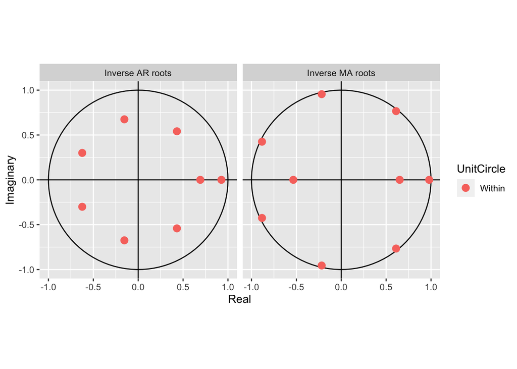

```r
autoplot(auto)
```

```r
air_visit_store1 <- sqldf("select distinct air_store_id,
                      longitude,latitude ,air_genre_name
                      from air_visit_store
                          ")
leaflet(air_visit_store1) %>%
  addTiles() %>%
  addProviderTiles("CartoDB.Positron") %>%
  addMarkers(~longitude, ~latitude,
             popup = ~air_store_id, label = ~air_genre_name,
             clusterOptions = markerClusterOptions())
```

[interactive chart not shown]

## HPG Restaurants

```r
head(hpg_reserve)
```

```
##           hpg_store_id      visit_datetime    reserve_datetime
## 1 hpg_c63f6f42e088e50f 2016-01-01 11:00:00 2016-01-01 09:00:00
## 2 hpg_dac72789163a3f47 2016-01-01 13:00:00 2016-01-01 06:00:00
## 3 hpg_c8e24dcf51ca1eb5 2016-01-01 16:00:00 2016-01-01 14:00:00
## 4 hpg_24bb207e5fd49d4a 2016-01-01 17:00:00 2016-01-01 11:00:00
## 5 hpg_25291c542ebb3bc2 2016-01-01 17:00:00 2016-01-01 03:00:00
## 6 hpg_28bdf7a336ec6a7b 2016-01-01 17:00:00 2016-01-01 15:00:00
##   reserve_visitors
## 1                1
## 2                3
## 3                2
## 4                5
## 5               13
## 6                2
```

```r
head(hpg_store_info)
```

```
##           hpg_store_id hpg_genre_name                 hpg_area_name
## 1 hpg_6622b62385aec8bf Japanese style Tōkyō-to Setagaya-ku Taishidō
## 2 hpg_e9e068dd49c5fa00 Japanese style Tōkyō-to Setagaya-ku Taishidō
## 3 hpg_2976f7acb4b3a3bc Japanese style Tōkyō-to Setagaya-ku Taishidō
## 4 hpg_e51a522e098f024c Japanese style Tōkyō-to Setagaya-ku Taishidō
## 5 hpg_e3d0e1519894f275 Japanese style Tōkyō-to Setagaya-ku Taishidō
## 6 hpg_530cd91db13b938e Japanese style Tōkyō-to Setagaya-ku Taishidō
##   latitude longitude
## 1 35.64367  139.6682
## 2 35.64367  139.6682
## 3 35.64367  139.6682
## 4 35.64367  139.6682
## 5 35.64367  139.6682
## 6 35.64367  139.6682
```

```r
#converting the datetime to a date so that i can merge with calendar date
hpg_reserve$visit_date <- as.Date(hpg_reserve$visit_datetime)
```

```r
hpg_visit_store <- sqldf("select a.*,
                                 hpg_genre_name,
                                 hpg_area_name,
                                 b.latitude,
                                 b.longitude,
                                 c.day_of_week,
                                 c.holiday_flg
                         from hpg_reserve a
                         left join hpg_store_info b
                         on a.hpg_store_id = b.hpg_store_id
                         left join date_info c
                on  a.visit_date = c.calendar_date")
```

## number of restaurants by genre - had to remove NAs while plotting as some restraurants do not have the information

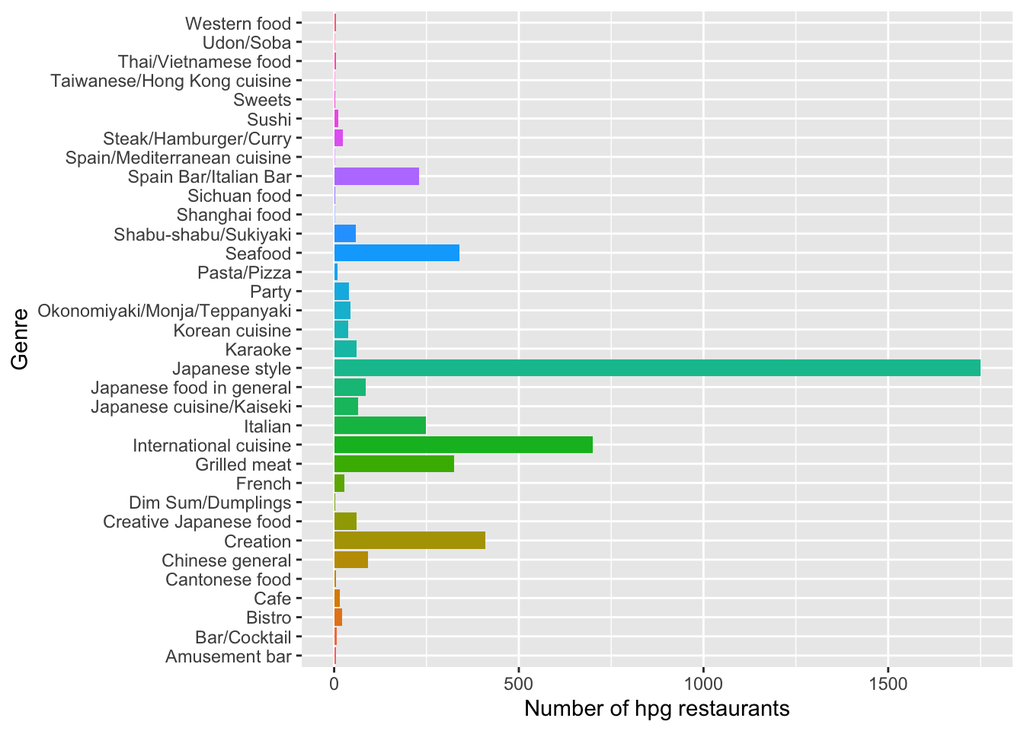

```r
hpg_visit_store %>%
   filter(!is.na(hpg_genre_name)) %>%
  group_by(hpg_genre_name) %>%
  summarize(stores = n_distinct(hpg_store_id)) %>%
  ggplot(aes(x = hpg_genre_name,  y = stores, fill = hpg_genre_name)) +
  geom_col() +
  coord_flip() +
  theme(legend.position = "none") +
  labs(x = "Genre", y = "Number of hpg restaurants")
```

International cuisine is second most common!

## number of restaurants by area

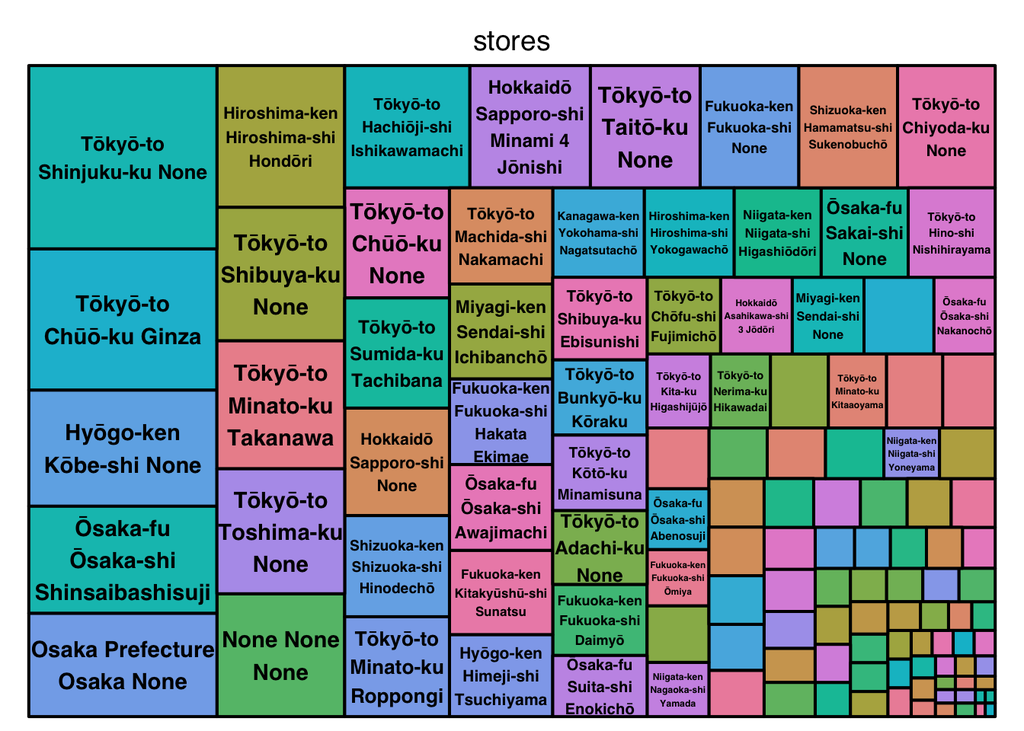

```r
hpg_visit_store %>%
  group_by(hpg_area_name) %>%
  summarize(stores = n_distinct(hpg_store_id)) %>%
  treemap(index="hpg_area_name",
        vSize="stores",
        type="index")
```

```r
head(hpg_visit_store)
```

```
##           hpg_store_id      visit_datetime    reserve_datetime
## 1 hpg_c63f6f42e088e50f 2016-01-01 03:00:00 2016-01-01 01:00:00
## 2 hpg_dac72789163a3f47 2016-01-01 05:00:00 2015-12-31 22:00:00
## 3 hpg_c8e24dcf51ca1eb5 2016-01-01 08:00:00 2016-01-01 06:00:00
## 4 hpg_24bb207e5fd49d4a 2016-01-01 09:00:00 2016-01-01 03:00:00
## 5 hpg_25291c542ebb3bc2 2016-01-01 09:00:00 2015-12-31 19:00:00
## 6 hpg_28bdf7a336ec6a7b 2016-01-01 09:00:00 2016-01-01 07:00:00
##   reserve_visitors visit_date hpg_genre_name                hpg_area_name
## 1                1 2016-01-01           <NA>                         <NA>
## 2                3 2016-01-01         French      Hyōgo-ken Kōbe-shi None
## 3                2 2016-01-01           <NA>                         <NA>
## 4                5 2016-01-01           <NA>                         <NA>
## 5               13 2016-01-01           <NA>                         <NA>
## 6                2 2016-01-01 Japanese style Fukuoka-ken Fukuoka-shi None
##   latitude longitude day_of_week holiday_flg
## 1       NA        NA      Friday           1
## 2 34.69211  135.1917      Friday           1
## 3       NA        NA      Friday           1
## 4       NA        NA      Friday           1
## 5       NA        NA      Friday           1
## 6 33.58981  130.4002      Friday           1
```

## Day of the week

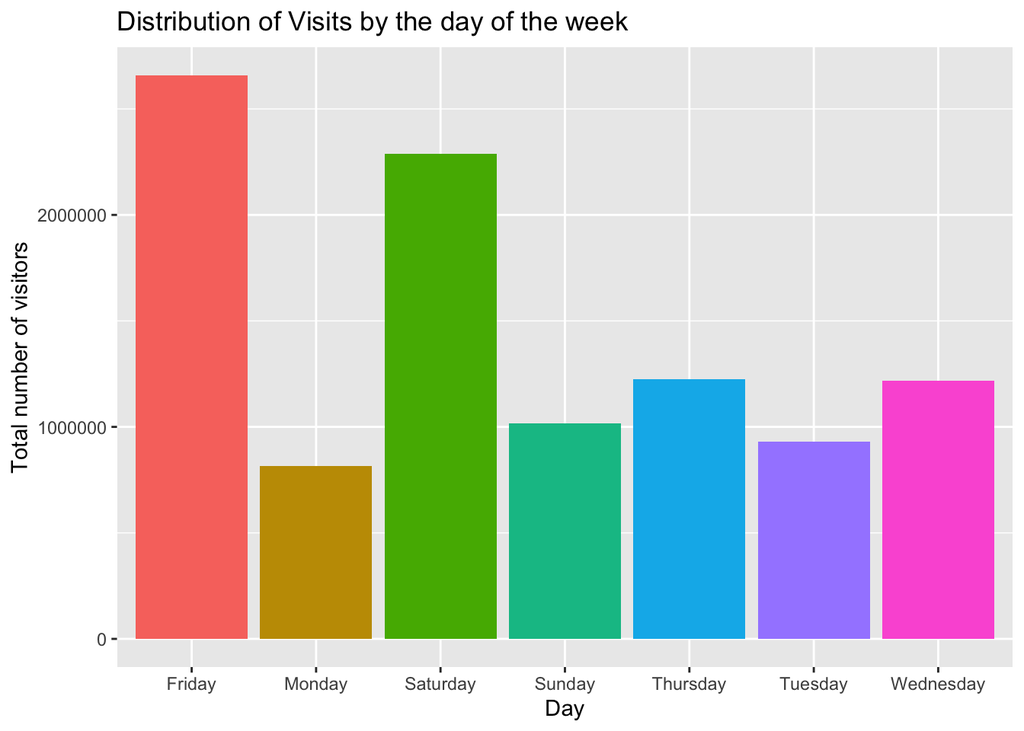

```r
hpg_visit_store %>%
  group_by(day_of_week) %>%
  summarise(visits = sum(reserve_visitors)) %>%
  ggplot(aes(day_of_week, visits, fill = day_of_week)) +
  geom_col() +
  theme(legend.position = "none") +
  labs(x = "Day", y = "Total number of visitors") +
  ggtitle("Distribution of Visits by the day of the week")
```

HPG restaurants are more popular on Friday instead.

##number of visits by genre - had to remove NAs while plotting as some restraurants do not have the information

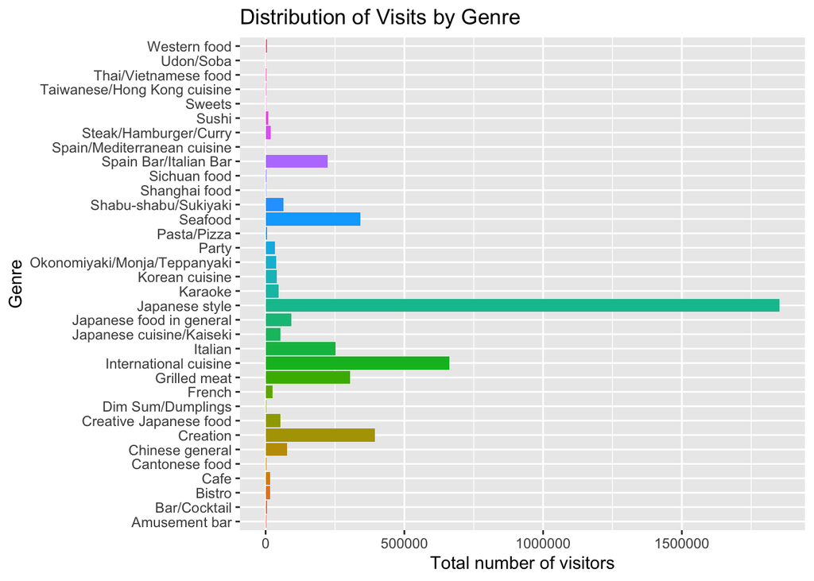

```r
hpg_visit_store %>%
     filter(!is.na(hpg_genre_name)) %>%
  group_by(hpg_genre_name) %>%
  summarise(visits = sum(reserve_visitors)) %>%
  ggplot(aes(hpg_genre_name, visits, fill = hpg_genre_name)) +
  geom_col() +
  theme(legend.position = "none") +
  labs(x = "Genre", y = "Total number of visitors") +
  ggtitle("Distribution of Visits by Genre")+
  coord_flip()
```

Japanese style and International Cuisine.

## Holidays

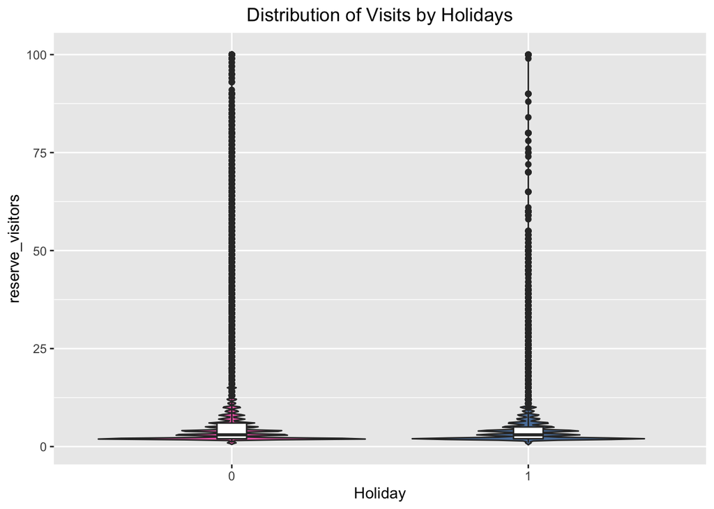

```r
test <- hpg_visit_store
test$holiday_flg <- as.factor(test$holiday_flg)
ggplot(test,aes(x = holiday_flg,y = reserve_visitors, fill = holiday_flg, group = holiday_flg))+
  geom_violin(trim=FALSE, alpha = 0.7) +
  theme(legend.position="none")+
  ggtitle("Distribution of Visits by Holidays")+
  theme(plot.title=element_text(hjust=0.5))+
  geom_boxplot(width=0.1,fill="white")+
  scale_fill_manual(values=c("#F2359D", "#034C8C")) +
  xlab("Holiday")
```

## Maybe mean visitors is better for visualization

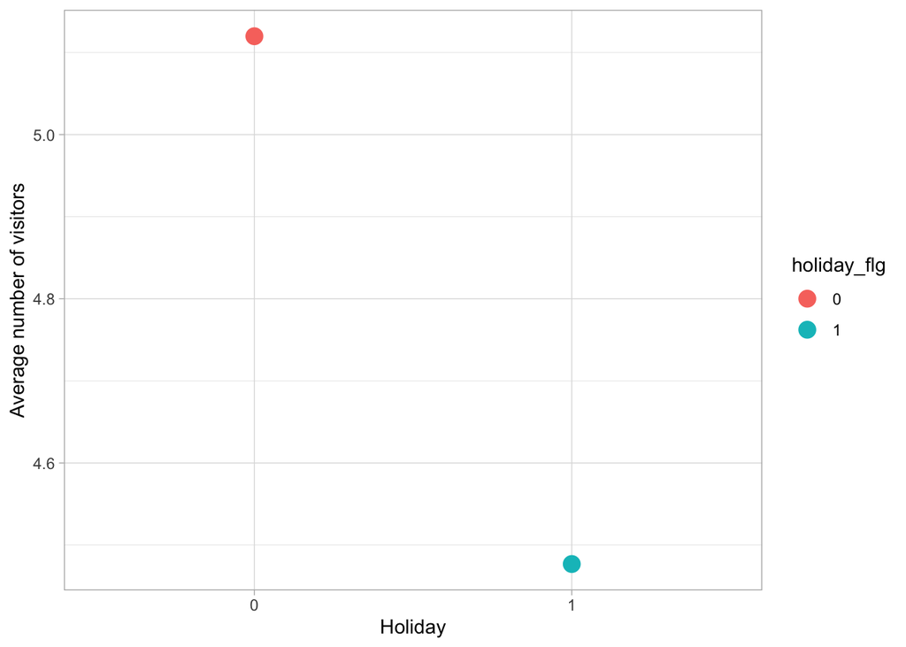

```r
test <- hpg_visit_store
test$holiday_flg <- as.factor(test$holiday_flg)
test %>%
  group_by( holiday_flg) %>%
  summarise(mean_visitors = mean(reserve_visitors)) %>%
  ggplot(aes(x=holiday_flg, y=mean_visitors, color=holiday_flg)) +
    geom_point(size=4) +
  xlab("Holiday")+
  ylab("Average number of visitors")+
  theme_light()
```

On an average, visits are more on a non holiday than a holiday ## Holidays on weekdays

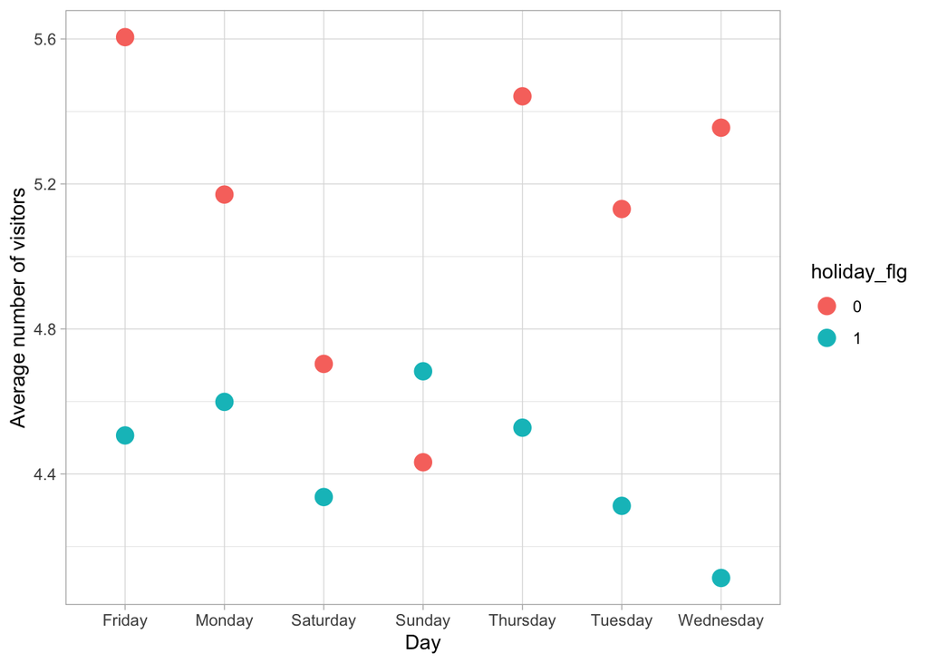

```r
test <- hpg_visit_store
test$holiday_flg <- as.factor(test$holiday_flg)
test %>%
  group_by(day_of_week, holiday_flg) %>%
  summarise(mean_visitors = mean(reserve_visitors)) %>%
  ggplot(aes(x=day_of_week, y=mean_visitors, color=holiday_flg)) +
    geom_point(size=4) +
  xlab("Day")+
  ylab("Average number of visitors")+
  theme_light()
```

```r
##R studio crases when I run this
# hpg_visit_store1 <-
#   hpg_visit_store %>%
# filter(!is.na(hpg_genre_name))
#
# leaflet(hpg_visit_store1) %>%
#   addTiles() %>%
#   addProviderTiles("CartoDB.Positron") %>%
#   addMarkers(~longitude, ~latitude,
#              popup = ~hpg_store_id, label = ~hpg_genre_name,
#              clusterOptions = markerClusterOptions())
```

## Time series

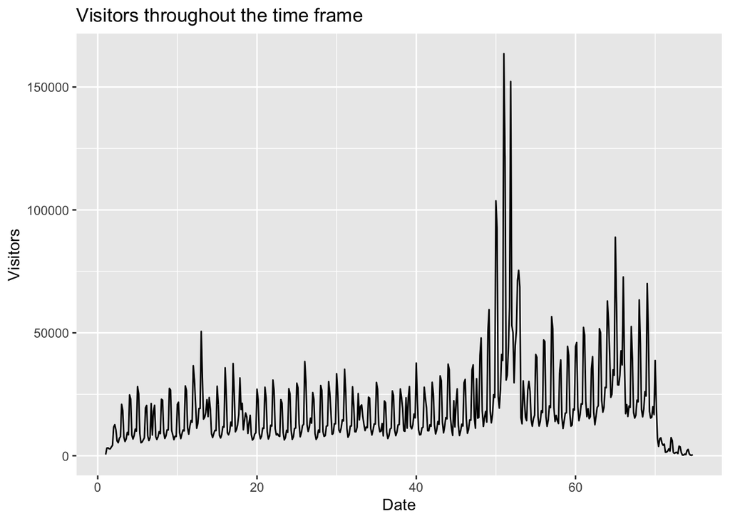

```r
hpg_vis <- subset(hpg_visit_store, select = c("visit_date","reserve_visitors"))
hpg_vis1 <- hpg_vis %>%
  group_by(visit_date) %>%
  summarize(visits = sum(reserve_visitors))

hpg_vis_ts <- ts(hpg_vis1[,2], frequency = 7)
autoplot(hpg_vis_ts) + xlab("Date") + ylab("Visitors") + ggtitle("Visitors throughout the time frame")
```

```r
auto <- auto.arima(hpg_vis_ts)
summary(auto)
```

```
## Series: hpg_vis_ts
## ARIMA(4,1,3)(0,0,2)[7]
##
## Coefficients:
##          ar1      ar2    ar3      ar4      ma1     ma2      ma3    sma1
##       1.2540  -1.1600  0.218  -0.1571  -1.9733  1.8035  -0.6223  0.3539
## s.e.  0.0894   0.0839  0.074   0.0679   0.0842  0.1126   0.0737  0.0498
##         sma2
##       0.1024
## s.e.  0.0427
##
## sigma^2 estimated as 103107917:  log likelihood=-5490.54
## AIC=11001.08   AICc=11001.51   BIC=11043.54
##
## Training set error measures:
##                     ME     RMSE      MAE       MPE     MAPE      MASE
## Training set -9.536121 10055.52 5567.173 -5.604494 44.58963 0.9133057
##                     ACF1
## Training set 0.004359805
```

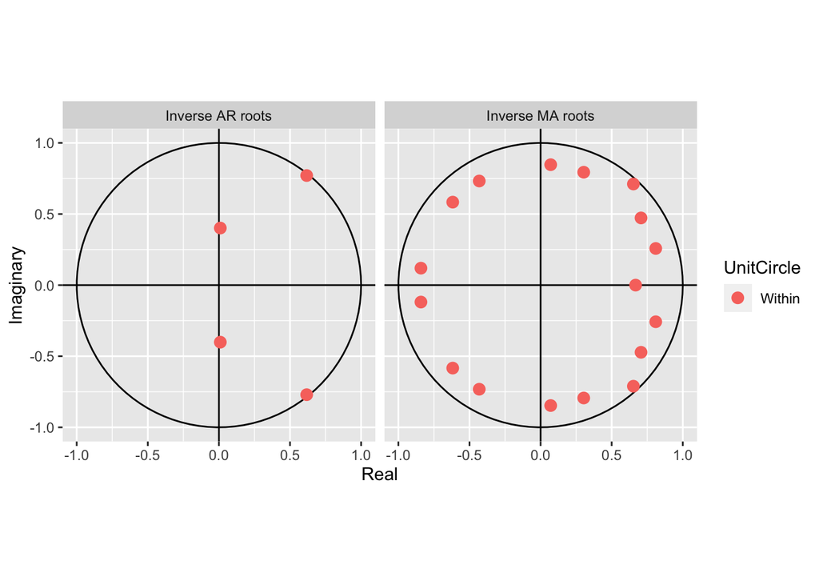

```r
autoplot(auto)
```